# portfolio 6

2023-04-13

```r
library(readxl)

library(ggplot2)

df <- read_excel("/Users/lindsaystall/Downloads/PIRUS_Public_May2020.xlsx")
df[df == -99 | df == -88] <- NA
```

```r
count <- sum(df$Changing_Target == 1, na.rm = TRUE)

cat("Number of times Changing_Target had a value of 1:", count)
```

```
## Number of times Changing_Target had a value of 1: 129
```

Now I know that in this dataset, there were 129 instances of terrorists changing their targets over time. I want to figure out what groups these people belonged to.

```r
df_filtered <- df[df$Changing_Target == 1,]

group_names <- unique(df_filtered$Terrorist_Group_Name1)

cat("Terrorist_Group_Names with Members who changed their targets:", paste(group_names, collapse = ", "))
```

[output not shown]

```r
sort(unique(df_filtered$Terrorist_Group_Name1))
```

```
##  [1] "al-Qaeda core"
##  [2] "Al-Qaeda in Iraq"
##  [3] "al-Qaeda in the Arabian Peninsula (AQAP)"
##  [4] "al-Shabaab"
##  [5] "Alaska Peacemakers Militia"
##  [6] "Animal Liberation Front (ALF)"
##  [7] "Armed Forces of National Liberation (FALN)"
##  [8] "Armed Revolutionary Independence Movement (MIRA)"
##  [9] "Army of God"
## [10] "Aryan Nations"
## [11] "Aryan Republican Army"
## [12] "Black Liberation Army"
## [13] "Black Panther Party"
## [14] "Council of Conservative Citizens"
## [15] "Earth Liberation Front (ELF)"
## [16] "Forever Enduring Always Ready (FEAR)"
## [17] "Islamic State of Iraq and the Levant (ISIL)"
## [18] "Jewish Defense League (JDL)"
## [19] "Ku Klux Klan"
## [20] "Lashkar-e Tayyiba (LeT)"
## [21] "National Alliance"
## [22] "Republic of Texas"
## [23] "Sovereign Citizens"
## [24] "Symbionese Liberation Army (SLA)"
## [25] "Taliban"
## [26] "The Covenant, The Sword, and the Arm of the Lord (CSA)"
## [27] "The Order (Silent Brotherhood)"
## [28] "The Order II (Bruder Schweigen Strike Force II)"
## [29] "The United Freedom Front (UFF)"
## [30] "Weather Underground"
```

That said, the codebook for this data doesnt specify the direction of this movement (did they start in this group or end in this group?)

```r
count <- sum(df$Anticp_Fatals_Targ == 1, na.rm = TRUE)

cat("Number of times Anticipated_Fatalities_Target had a value of 1:", count)
```

```
## Number of times Anticipated_Fatalities_Target had a value of 1: 491
```

Most (491) terrorist plots in this dataset anticipated to kill some victims, which was about 1-20

```r
count <- sum(df$Anticp_Fatals_Targ == 2, na.rm = TRUE)

cat("Number of times Anticipated_Fatalities_Target had a value of 1:", count)
```

```
## Number of times Anticipated_Fatalities_Target had a value of 1: 106
```

```r
count <- sum(df$Anticp_Fatals_Targ == 3, na.rm = TRUE)

cat("Number of times Anticipated_Fatalities_Target had a value of 1:", count)
```

```
## Number of times Anticipated_Fatalities_Target had a value of 1: 101
```

Terrorist plots in this dataset anticipated to kill many victims (over 20) (106) or a mass amount of victims (over 100) (101) were about equal in number.

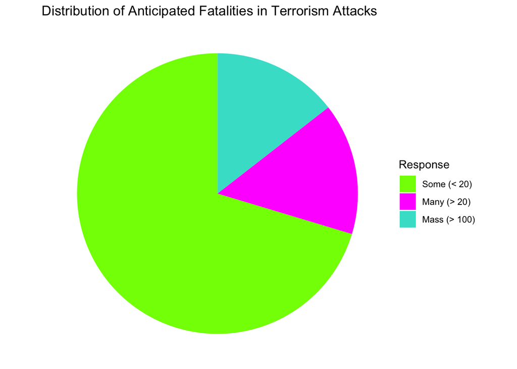

```r
pie_data <- df %>%
  filter(Anticp_Fatals_Targ %in% c(1,2,3)) %>%
  group_by(Anticp_Fatals_Targ) %>%
  summarise(n = n())

ggplot(pie_data, aes(x="", y=n, fill=factor(Anticp_Fatals_Targ))) +
  geom_bar(stat="identity", width=1) +
  coord_polar("y", start=0) +
  scale_fill_manual(values = c("chartreuse", "magenta", "turquoise"),
                    labels = c("Some (< 20)", "Many (> 20)", "Mass (> 100)")) +
  labs(title="Distribution of Anticipated Fatalities in Terrorism Attacks",
       fill="Response",
       x=NULL,
       y=NULL) +
  theme_void()
```